# Homework 01

## Question 1 (Least squares and matrix calculations)

Set the random seed to $43201$. Generate $n=100$ observations with $p=5$ predictors according to

$$x_{ij}\overset{\mathrm{iid}}{\sim}N(0,1),
\qquad
\varepsilon_i\overset{\mathrm{iid}}{\sim}N(0,0.7^2),$$

with all predictors and errors generated independently. Let

$$\mathbf X
=
\begin{bmatrix}
\mathbf 1 & \mathbf x_1 & \cdots & \mathbf x_5
\end{bmatrix},
\qquad
\boldsymbol\beta
=
(3,1.4,-0.9,0.7,0,1.1)^{\mathsf T},$$

and generate

$$\mathbf y=\mathbf X\boldsymbol\beta+\boldsymbol\varepsilon.$$

1. Generate the data and report the dimensions and rank of $\mathbf X$. Calculate the least-squares estimate $\widehat{\boldsymbol\beta}$ using a numerically stable least-squares routine, without explicitly calculating $(\mathbf X^{\mathsf T}\mathbf X)^{-1}$. Compare the estimates with the coefficients used to generate the data.

```r
set.seed(43201)
n <- 100
p <- 5

X_pred <- matrix(rnorm(n * p), nrow = n, ncol = p)
X <- cbind(1, X_pred)

beta <- c(3, 1.4, -0.9, 0.7, 0, 1.1)
eps <- rnorm(n, mean = 0, sd = 0.7)
y <- X %*% beta + eps

dim(X)
```

```
[1] 100   6
```

```r
qr(X)$rank
```

```
[1] 6
```

```r
fit <- lm(y ~ X - 1)
beta_hat <- coef(fit)
beta_hat
```

```
        X1         X2         X3         X4         X5         X6
 3.0063210  1.4171604 -0.8883453  0.7952834  0.0484378  1.1319341
```

$\mathbf X$ has $100$ rows and $6$ columns (an intercept column plus five predictor columns), and it has full column rank $6$. The estimated coefficients,

$$\widehat{\boldsymbol\beta} \approx (3.006,\; 1.417,\; -0.888,\; 0.795,\; 0.048,\; 1.132)^{\mathsf T},$$

closely recover the true coefficients used to generate the data, $\boldsymbol\beta=(3,1.4,-0.9,0.7,0,1.1)^{\mathsf T}$ — every estimated coefficient is within about $0.1$ of the truth, including the coefficient on the predictor with true value $0$, which is correctly estimated near zero ($0.048$). This close agreement is expected with $n=100$ observations and a modest noise level ($\sigma=0.7$).

2. Calculate the fitted values, the residual vector $\mathbf r=\mathbf y-\mathbf X\widehat{\boldsymbol\beta}$, and the training root mean squared error

$$\operatorname{RMSE}
=
\left(
\frac{1}{n}\sum_{i=1}^{n}r_i^2
\right)^{1/2}.$$

```r
y_hat <- X %*% beta_hat
r <- y - y_hat
rmse <- sqrt(mean(r^2))
rmse
```

```
[1] 0.6763696
```

The training RMSE is approximately $0.676$, which is reasonably close to the true noise standard deviation $\sigma=0.7$ used to generate $\boldsymbol\varepsilon$.

3. Report $\lVert\mathbf X^{\mathsf T}\mathbf r\rVert_\infty$. Explain why this value should be close to zero and what it tells us about the residual vector.

```r
inf_norm <- max(abs(t(X) %*% r))
inf_norm
```

```
[1] 5.878631e-14
```

The infinity norm is approximately $5.88\times 10^{-14}$, which is effectively zero up to floating-point precision. This is expected because the least-squares solution $\widehat{\boldsymbol\beta}$ is defined by the normal equations $\mathbf X^{\mathsf T}(\mathbf y - \mathbf X\widehat{\boldsymbol\beta}) = \mathbf X^{\mathsf T}\mathbf r = \mathbf 0$. In other words, the residual vector is exactly orthogonal to every column of $\mathbf X$ (the intercept and all five predictors). Geometrically, $\mathbf X\widehat{\boldsymbol\beta}$ is the orthogonal projection of $\mathbf y$ onto the column space of $\mathbf X$, so the leftover piece $\mathbf r$ must lie entirely in the space orthogonal to that column space, and $\lVert\mathbf X^{\mathsf T}\mathbf r\rVert_\infty \approx 0$ simply confirms this optimality condition numerically.

## Question 2 (Gaussian likelihood for linear regression)

Continue with the data from Question 1. Suppose

$$\mathbf Y\mid\mathbf X
\sim
N_n\left(\mathbf X\boldsymbol\beta,\sigma^2\mathbf I_n\right).$$

The log-likelihood, including the constant term, is

$$\ell(\boldsymbol\beta,\sigma^2)
=
-\frac{n}{2}\log(2\pi\sigma^2)
-\frac{1}{2\sigma^2}
(\mathbf y-\mathbf X\boldsymbol\beta)^{\mathsf T}
(\mathbf y-\mathbf X\boldsymbol\beta).$$

1. For fixed $\sigma^2$, explain why maximizing $\ell(\boldsymbol\beta,\sigma^2)$ over $\boldsymbol\beta$ is equivalent to minimizing the residual sum of squares. What does this imply about the maximum-likelihood estimate of $\boldsymbol\beta$?

For fixed $\sigma^2$, the first term $-\frac{n}{2}\log(2\pi\sigma^2)$ does not depend on $\boldsymbol\beta$ at all, so it can be treated as a constant. The second term, $-\frac{1}{2\sigma^2}(\mathbf y-\mathbf X\boldsymbol\beta)^{\mathsf T}(\mathbf y-\mathbf X\boldsymbol\beta)$, is a negative constant ($-1/2\sigma^2$) multiplied by the residual sum of squares, $\operatorname{RSS}(\boldsymbol\beta)$. Maximizing a negative multiple of $\operatorname{RSS}(\boldsymbol\beta)$ over $\boldsymbol\beta$ is equivalent to minimizing $\operatorname{RSS}(\boldsymbol\beta)$ over $\boldsymbol\beta$. This means the maximum-likelihood estimate of $\boldsymbol\beta$ is exactly the ordinary least-squares estimator $\widehat{\boldsymbol\beta}$ from Question 1 — the two estimation approaches (maximum likelihood and least squares) produce the identical point estimate for $\boldsymbol\beta$ in this model.

2. For fixed $\boldsymbol\beta$, differentiate the log-likelihood with respect to $\sigma^2$ and derive its maximum-likelihood estimate. Calculate this estimate at $\widehat{\boldsymbol\beta}$ and compare it with the unbiased estimate of $\sigma^2$. Explain why the two denominators differ.

Writing $\log(2\pi\sigma^2) = \log(2\pi) + \log(\sigma^2)$ and differentiating with respect to $\sigma^2$:

$$\frac{\partial \ell}{\partial \sigma^2}
=
-\frac{n}{2\sigma^2}
+
\frac{1}{2\sigma^4}(\mathbf y-\mathbf X\boldsymbol\beta)^{\mathsf T}(\mathbf y-\mathbf X\boldsymbol\beta).$$

Setting this equal to zero and solving for $\sigma^2$ gives

$$\widehat{\sigma}^2_{\mathrm{MLE}}
=
\frac{1}{n}(\mathbf y-\mathbf X\boldsymbol\beta)^{\mathsf T}(\mathbf y-\mathbf X\boldsymbol\beta)
=
\frac{\operatorname{RSS}(\boldsymbol\beta)}{n}.$$

```r
sigma2_mle <- as.numeric(t(r) %*% r) / n
sigma2_mle
```

```
[1] 0.4574759
```

```r
sigma2_unbiased <- as.numeric(t(r) %*% r) / (n - ncol(X))
sigma2_unbiased
```

```
[1] 0.4866765
```

At $\widehat{\boldsymbol\beta}$, $\widehat{\sigma}^2_{\mathrm{MLE}} \approx 0.457$, while the unbiased estimate is $\widehat{\sigma}^2_{\text{unbiased}} \approx 0.487$. The two denominators differ because $\widehat{\sigma}^2_{\mathrm{MLE}}$ divides $\operatorname{RSS}(\widehat{\boldsymbol\beta})$ by $n$, while the unbiased estimator divides by $n - 6$, the residual degrees of freedom after estimating $6$ regression coefficients. Because $\widehat{\boldsymbol\beta}$ is chosen specifically to minimize $\operatorname{RSS}$ on this exact sample, it partially “absorbs” some of the noise in the data, making $\operatorname{RSS}(\widehat{\boldsymbol\beta})$ systematically smaller than it would be under the true $\boldsymbol\beta$. Dividing by $n$ does not correct for this, so $\widehat{\sigma}^2_{\mathrm{MLE}}$ is biased downward; dividing by $n-6$ instead compensates for the $6$ degrees of freedom used up in estimating $\boldsymbol\beta$, which is why $\widehat{\sigma}^2_{\text{unbiased}} > \widehat{\sigma}^2_{\mathrm{MLE}}$. Indeed, the ratio of the two estimates, $0.487/0.457 \approx 1.064$, matches $n/(n-6) = 100/94 \approx 1.064$ almost exactly.

3. Let

$$\mathbf e_{x_2}=(0,0,1,0,0,0)^{\mathsf T}.$$

Using the variance estimate from part b, plot

$$\ell\left(
\widehat{\boldsymbol\beta}+t\mathbf e_{x_2},
\widehat{\sigma}_{\mathrm{MLE}}^2
\right)$$

over a grid of $t$ values from $-1.25$ to $1.25$. State where the maximum occurs and explain why this agrees with the least-squares result.

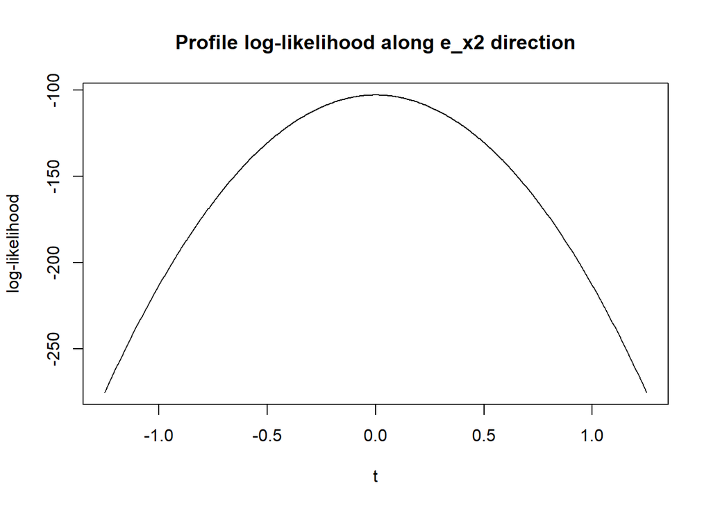

```r
e_x2 <- c(0, 0, 1, 0, 0, 0)

loglik <- function(t) {
  beta_t <- beta_hat + t * e_x2
  resid_t <- y - X %*% beta_t
  rss_t <- as.numeric(t(resid_t) %*% resid_t)
  -n/2 * log(2 * pi * sigma2_mle) - rss_t / (2 * sigma2_mle)
}

t_grid <- seq(-1.25, 1.25, length.out = 501)
ll_vals <- sapply(t_grid, loglik)

plot(t_grid, ll_vals, type = "l",
     xlab = "t", ylab = "log-likelihood",
     main = "Profile log-likelihood along e_x2 direction")
```

```r
t_grid[which.max(ll_vals)]
```

```
[1] 0
```

The profile log-likelihood traces out a smooth, symmetric, downward-opening parabola in $t$, peaking exactly at $t=0$. This maximum at $t=0$ agrees with the least-squares result because $\widehat{\boldsymbol\beta}$ (the OLS/MLE estimator from Questions 1–2a) already maximizes the log-likelihood over all of $\boldsymbol\beta$-space; perturbing only the third coordinate of $\widehat{\boldsymbol\beta}$ by an amount $t$ (i.e., moving along $\mathbf e_{x_2}$) can therefore only ever decrease $\ell$, regardless of the sign of $t$. The symmetry of the curve is also structural rather than coincidental: since $\ell$ depends on $t$ only through the quadratic residual sum of squares $(\mathbf y - \mathbf X(\widehat{\boldsymbol\beta}+t\mathbf e_{x_2}))^{\mathsf T}(\mathbf y - \mathbf X(\widehat{\boldsymbol\beta}+t\mathbf e_{x_2}))$, the log-likelihood is exactly a downward parabola in $t$, guaranteeing a single, symmetric maximum — precisely at the OLS solution.

## Question 3 (Starting values in nonconvex optimization)

Consider the function

$$f(x)=\exp(1.5x)-3(x+6)^2-0.05x^3,$$

with derivative

$$f'(x)=1.5\exp(1.5x)-6(x+6)-0.15x^2.$$

1. Plot $f(x)$ over the interval $[-40,7]$. Based on the plot, describe the important features of the objective function that may affect numerical optimization.

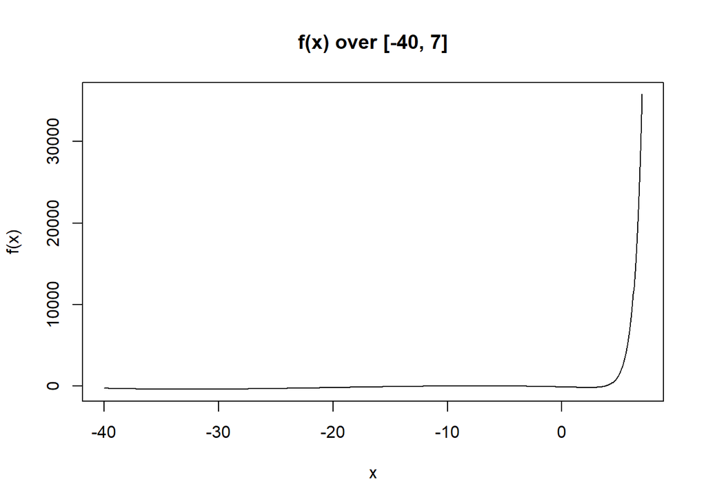

```r
f <- function(x) exp(1.5 * x) - 3 * (x + 6)^2 - 0.05 * x^3
f_prime <- function(x) 1.5 * exp(1.5 * x) - 6 * (x + 6) - 0.15 * x^2

x_grid <- seq(-40, 7, length.out = 1000)
plot(x_grid, f(x_grid), type = "l",
     xlab = "x", ylab = "f(x)",
     main = "f(x) over [-40, 7]")
```

At this scale, $f(x)$ appears nearly flat across almost the entire interval and then rises extremely steeply as $x$ approaches $7$, reaching values above $30{,}000$. This steep behavior is driven by the $\exp(1.5x)$ term, which dominates the function for larger $x$. Because that term compresses the vertical scale so much, the more subtle local structure of $f$ over the rest of the domain — including local minima — is essentially invisible on this plot. Zooming in on a narrower $y$-range reveals this local structure more clearly:

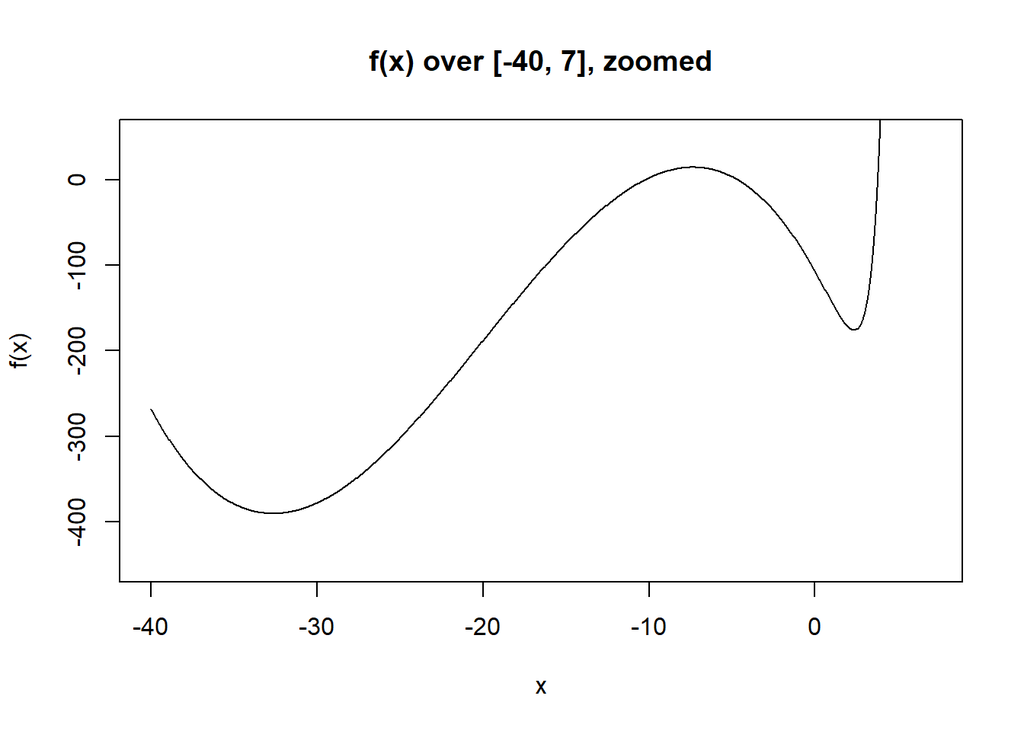

```r
plot(x_grid, f(x_grid), type = "l", ylim = c(-450, 50),
     xlab = "x", ylab = "f(x)",
     main = "f(x) over [-40, 7], zoomed")
```

On the zoomed plot, $f$ has at least two local minima — one further left and a shallower one closer to $x=0$ — with a local maximum somewhere between them. These are the important features affecting numerical optimization: the function is **nonconvex**, containing multiple basins of attraction, so a local gradient-based method like BFGS is not guaranteed to find the same minimum (or the global minimum) from different starting points; the eventual answer depends on which basin the starting value falls into. The steep rise near $x=7$ is also important practically, since a starting value too close to that region could produce very large gradients early in the optimization.

2. Use BFGS to minimize $f(x)$ twice, starting at $x^{(0)}=-15$ and $x^{(0)}=0$. Supply $f'(x)$ to the optimizer. For each run, report the final value of $x$, the final objective value, $|f'(x)|$, and whether the optimizer reported convergence.

```r
res1 <- optim(par = -15, fn = f, gr = f_prime, method = "BFGS")
res2 <- optim(par = 0, fn = f, gr = f_prime, method = "BFGS")

res1$par; res1$value; abs(f_prime(res1$par)); res1$convergence
```

```
[1] -32.64911
```

```
[1] -390.3858
```

```
[1] 8.725087e-08
```

```
[1] 0
```

```r
res2$par; res2$value; abs(f_prime(res2$par)); res2$convergence
```

```
[1] 2.349967
```

```
[1] -175.8626
```

```
[1] 6.556057e-07
```

```
[1] 0
```

| Start | $x^\ast$ | $f(x^\ast)$ | $\lvert f'(x^\ast)\rvert$ | Convergence |
| --- | --- | --- | --- | --- |
| $x^{(0)}=-15$ | $-32.649$ | $-390.386$ | $8.73\times10^{-8}$ | $0$ (converged) |
| $x^{(0)}=0$ | $2.350$ | $-175.863$ | $6.56\times10^{-7}$ | $0$ (converged) |

Both runs report successful convergence (`convergence = 0`), and both gradients are essentially zero, confirming each run reached a genuine stationary point.

3. Explain why the two runs can converge to different answers. Which run gives the lower objective value? What additional evidence would be needed before claiming that this point is the global minimum?

The two runs converge to different answers because $f$ is nonconvex, as seen in part (a) — it has multiple local minima separated by a local maximum. BFGS is a local optimization method: starting from $x^{(0)}=-15$ places the search in the basin surrounding the deeper minimum near $x\approx-32.6$, while starting from $x^{(0)}=0$ places it in the basin surrounding the shallower minimum near $x\approx 2.35$. Each run simply follows the local gradient downhill within whichever basin it started in.

The run starting at $x^{(0)}=-15$ gives the lower objective value ($f(x^\ast)\approx-390.39$ versus $\approx-175.86$). However, this alone does not establish that $x\approx-32.65$ is the **global** minimum over $[-40,7]$ — it only shows this point is lower than the other local minimum found. To gain confidence that it is the global minimum, additional evidence would be needed, such as: (1) running BFGS from many more starting values spread across the interval (a multi-start search) and confirming none produces an even lower objective value, or (2) directly inspecting the zoomed plot across the full interval to visually confirm no other region dips below $\approx-390$, including checking the behavior of $f$ as $x\to-40$.

## Question 4 (Nearly collinear predictors)

Continue with $\mathbf X$ and $\mathbf y$ from Question 1. Set the random seed to $43202$ and generate

$$u_i\overset{\mathrm{iid}}{\sim}N(0,1),
\qquad i=1,\ldots,n.$$

Define

$$\mathbf x_6=\mathbf x_1+10^{-4}\mathbf u,
\qquad
\mathbf X_+
=
\begin{bmatrix}
\mathbf X & \mathbf x_6
\end{bmatrix},$$

and let

$$\mathbf y^\star=\mathbf y+10^{-3}\mathbf u.$$

Use a numerically stable least-squares routine throughout.

1. Fit $\mathbf y$ using $\mathbf X$ and $\mathbf X_+$. For each design matrix, report the condition number and training RMSE. For the augmented fit, also report the coefficients of $\mathbf x_1$ and $\mathbf x_6$.

```r
set.seed(43202)
u <- rnorm(n)

x6 <- X[, 2] + 1e-4 * u   # column 2 of X is x1
X_plus <- cbind(X, x6)

y_star <- y + 1e-3 * u

cond_X <- kappa(X)
cond_X_plus <- kappa(X_plus)

fit_X <- lm(y ~ X - 1)
fit_Xplus <- lm(y ~ X_plus - 1)

rmse_X <- sqrt(mean(residuals(fit_X)^2))
rmse_Xplus <- sqrt(mean(residuals(fit_Xplus)^2))

cond_X; cond_X_plus; rmse_X; rmse_Xplus
```

```
[1] 1.950478
```

```
[1] 31344.8
```

```
[1] 0.6763696
```

```
[1] 0.6754668
```

```r
coef(fit_Xplus)[2]  # x1 coefficient
```

```
  X_plus
351.6766
```

```r
coef(fit_Xplus)[7]  # x6 coefficient
```

```
 X_plusx6
-350.2588
```

| Quantity | $\mathbf X$ | $\mathbf X_+$ |
| --- | --- | --- |
| Condition number | $1.950$ | $31{,}344.8$ |
| Training RMSE | $0.6764$ | $0.6755$ |

For the augmented fit, the coefficient on $\mathbf x_1$ is $\approx 351.68$ and the coefficient on $\mathbf x_6$ is $\approx -350.26$.

The condition number jumps enormously, from about $1.95$ for $\mathbf X$ to over $31{,}000$ for $\mathbf X_+$, reflecting that adding $\mathbf x_6 \approx \mathbf x_1$ makes the design matrix nearly rank-deficient. Meanwhile the training RMSE barely changes ($0.6764 \to 0.6755$), since $\mathbf x_6$ carries almost no additional information beyond what $\mathbf x_1$ already provides.

2. Fit $\mathbf y^\star$ using $\mathbf X_+$. Report the changes in the coefficients of $\mathbf x_1$ and $\mathbf x_6$. Compare the two fitted-value vectors using their root mean squared difference and maximum absolute difference.

```r
fit_Xplus_star <- lm(y_star ~ X_plus - 1)

coef(fit_Xplus_star)[2]  # x1 coefficient
```

```
  X_plus
341.6766
```

```r
coef(fit_Xplus_star)[7]  # x6 coefficient
```

```
 X_plusx6
-340.2588
```

```r
fitted_diff <- fitted(fit_Xplus_star) - fitted(fit_Xplus)
rmsd <- sqrt(mean(fitted_diff^2))
max_abs_diff <- max(abs(fitted_diff))
rmsd; max_abs_diff
```

```
[1] 0.001015879
```

```
[1] 0.002572675
```

| Coefficient | Fit on $\mathbf y$ | Fit on $\mathbf y^\star$ | Change |
| --- | --- | --- | --- |
| $\mathbf x_1$ | $351.68$ | $341.68$ | $-10.0$ |
| $\mathbf x_6$ | $-350.26$ | $-340.26$ | $+10.0$ |

The coefficient on $\mathbf x_1$ decreases by about $10$, while the coefficient on $\mathbf x_6$ increases by about $10$ — equal and opposite shifts. Meanwhile, the two fitted-value vectors are nearly identical: the root mean squared difference is $\approx 0.00102$ and the maximum absolute difference is only $\approx 0.00257$.

3. Use the identity

$$\mathbf y^\star-\mathbf y
=
10(\mathbf x_6-\mathbf x_1)$$

to explain why the fitted values change very little while the two coefficients change substantially. What does this example suggest about interpreting separate effects for nearly collinear predictors?

Since $\mathbf x_6 = \mathbf x_1 + 10^{-4}\mathbf u$ and $\mathbf y^\star = \mathbf y + 10^{-3}\mathbf u$, we have $\mathbf u = (\mathbf x_6-\mathbf x_1)/10^{-4}$, so $\mathbf y^\star - \mathbf y = 10^{-3}\cdot(\mathbf x_6-\mathbf x_1)/10^{-4} = 10(\mathbf x_6-\mathbf x_1)$. This means the entire change in the response between $\mathbf y$ and $\mathbf y^\star$ can be exactly reproduced by adding $10$ to the coefficient on $\mathbf x_6$ and subtracting $10$ from the coefficient on $\mathbf x_1$ (or some similar combination), because $\mathbf x_1$ and $\mathbf x_6$ are nearly identical numerically. Since $\mathbf x_1\approx \mathbf x_6$, the combination $\beta_1\mathbf x_1 + \beta_6\mathbf x_6 \approx (\beta_1+\beta_6)\mathbf x_1$ depends essentially only on the *sum* $\beta_1+\beta_6$, not on the individual values — so the model can absorb the shift in $\mathbf y^\star$ entirely through large, offsetting changes in $\beta_1$ and $\beta_6$ that leave their sum, and therefore the fitted values, almost unchanged. This is exactly what was observed: the coefficients swing by $\mp 10$ while the fitted values shift by less than $0.003$ at most.

This example shows that when predictors are nearly collinear, the model cannot separately identify their individual coefficients — only certain combinations of them (here, their sum) are well-determined by the data. Individual coefficient estimates in this setting are numerically unstable and should not be interpreted as isolated, reliable “effects” of each predictor; only jointly identifiable combinations, or the model’s overall predictions, can be trusted.

## Question 5 (Data preparation and summary statistics)

The file `data/data-manipulation.csv` is a small constructed data table containing an observation identifier, a group label, two numeric predictors, and a response. Some response values are missing. For analyses involving the response, use only observations with a recorded response. Do not replace a missing response with zero or a group mean.

1. Read the data and report its dimensions, column types, number of duplicated identifiers, and number of missing values in each column. Create an analysis table containing only observations with a recorded response, and define

$$\texttt{feature\_sum}=\texttt{x1}+\texttt{x2}.$$

```r
library(readr)
library(dplyr)
dat <- read_csv("data/data-manipulation.csv")
dim(dat)
```

```
[1] 24  5
```

```r
sapply(dat, class)
```

```
observation_id          group             x1             x2       response
   "character"    "character"      "numeric"      "numeric"      "numeric"
```

```r
sum(duplicated(dat$observation_id))
```

```
[1] 0
```

```r
colSums(is.na(dat))
```

```
observation_id          group             x1             x2       response
             0              0              0              0              3
```

```r
analysis <- dat %>%
  filter(!is.na(response)) %>%
  mutate(feature_sum = x1 + x2)
```

The data has $24$ rows and $5$ columns. Column types are: `observation_id` (character), `group` (character), `x1` (numeric), `x2` (numeric), and `response` (numeric). There are no duplicated observation identifiers. Missing values by column: `observation_id` (0), `group` (0), `x1` (0), `x2` (0), `response` (3).

2. For each group, report the number of observations, the mean response, and the mean of `feature_sum`. State clearly which observations these summaries describe.

```r
group_summary <- analysis %>%
  group_by(group) %>%
  summarise(
    n_obs = n(),
    mean_response = mean(response),
    mean_feature_sum = mean(feature_sum)
  )
group_summary
```

```
# A tibble: 3 × 4
  group n_obs mean_response mean_feature_sum
  <chr> <int>         <dbl>            <dbl>
1 A         7          5.6              3.6
2 B         7          7.60             4.93
3 C         7          8.00             6.59
```

| Group | n_obs | mean_response | mean_feature_sum |
| --- | --- | --- | --- |
| A | 7 | 5.60 | 3.60 |
| B | 7 | 7.60 | 4.93 |
| C | 7 | 8.00 | 6.59 |

These summaries describe only the $21$ observations that have a recorded (non-missing) `response` value. The three observations with a missing response (one in each group) are excluded entirely and do not contribute to any of these counts or means.

3. Sort the analysis table by response from largest to smallest and report the first three rows, including `observation_id`, `group`, `response`, and `feature_sum`. Add code checks verifying that the number of retained rows equals the number of nonmissing responses in the original data, that the analysis table has no missing response values, and that its identifiers are unique.

```r
top3 <- analysis %>%
  arrange(desc(response)) %>%
  select(observation_id, group, response, feature_sum) %>%
  slice_head(n = 3)
top3
```

```
# A tibble: 3 × 4
  observation_id group response feature_sum
  <chr>          <chr>    <dbl>       <dbl>
1 obs-22         C         9.24         6.6
2 obs-16         B         9            5.2
3 obs-14         B         8.66         5
```

```r
stopifnot(nrow(analysis) == sum(!is.na(dat$response)))
stopifnot(sum(is.na(analysis$response)) == 0)
stopifnot(length(unique(analysis$observation_id)) == nrow(analysis))
```

| observation_id | group | response | feature_sum |
| --- | --- | --- | --- |
| obs-22 | C | 9.24 | 6.6 |
| obs-16 | B | 9.00 | 5.2 |
| obs-14 | B | 8.66 | 5.0 |

All three checks pass silently: the analysis table retains exactly the $21$ rows with non-missing responses, contains no missing response values, and has unique identifiers.

## Question 6 (Can 39 million Fitbit records represent US adults?)

[Patten et al. (2026)](https://doi.org/10.1038/s41591-026-04352-3) describe Fitbit data from 59,018 participants in the All of Us Research Program. The dataset spans 14 years and contains more than 39 million daily step records. Participants contributed data through one of two routes:

- Bring Your Own Device (BYOD): participants shared data from a Fitbit they already owned.
- Wearables Enhancing All of Us Research (WEAR): invited participants received a Fitbit at no cost.

In the general activity cohort, the BYOD and WEAR groups contained 32,035 and 22,474 participants, respectively. The BYOD value is listed first in each comparison below:

- 77.3% versus 55.1% reported being White;
- 6.1% versus 15.2% reported annual household income between $\$10{,}000$ and $\$25{,}000$; and
- median daily steps were 6,867 versus 5,797.

Suppose the target is the mean of the participant-specific average daily step counts among US adults during the study period, with each adult given equal weight. A researcher writes:

> “This dataset contains more than 39 million daily Fitbit records. Therefore, the average of all recorded step counts should provide an accurate estimate of mean daily activity among US adults.”
1. Are the 39 million daily records independent observations? What characteristics or behaviors could cause some participants to contribute more recorded days than others? Explain how averaging all recorded days would then weight participants unequally.

No, the 39 million daily records are not independent observations. Each participant contributes many repeated daily records, and records from the same person are correlated with one another (a person who tends to walk a lot on one day likely tends to walk a lot on nearby days too), rather than being fresh, independent draws from the population. In addition, some participants will contribute far more recorded days than others — for example, more engaged, health-conscious, or retired participants, or those who simply remember to wear and charge their device consistently, will log many more days than someone who wears the device sporadically. If all daily records are averaged together directly, participants who contributed more days are implicitly given more weight in the overall average than participants who contributed few days, so the result is not a fair, equally-weighted average across participants — it is dominated by whichever participants happened to generate the most data.

2. BYOD participants reported a median of 6,867 daily steps, compared with 5,797 among WEAR participants. Does this comparison show that already owning a Fitbit causes people to walk more? Explain your answer and give at least one plausible alternative explanation based on how participants entered the two groups.

No, this comparison does not show that owning a Fitbit causes more walking. BYOD and WEAR are not randomly assigned groups — participants self-selected or were selected into each group based on whether they already owned a device, so this is an observational comparison, not a controlled experiment, and cannot establish causation. A plausible alternative explanation is that people who already owned a Fitbit before the study (BYOD) likely already had different underlying characteristics — for instance, being more health-conscious, physically active, or having greater financial means to have purchased a device in the first place — and it may be those pre-existing differences, rather than device ownership itself, that explain their higher step counts. WEAR participants, who received a free device specifically because they did not already own one, may differ systematically in ways (e.g., baseline activity level, income, or motivation) that are unrelated to the device itself but still associated with step counts.

3. A very large dataset can still produce a biased estimate of a population quantity when the people and observations entering the dataset are selected. Using this study, explain how selection of both participants and recorded days could make the observed data differ from the US adult population. Why might the naive average of all recorded daily step counts fail to estimate the stated target? You do not need to determine the direction of the bias.

There are two distinct layers of selection at play. First, who enrolls in the All of Us Research Program at all, and who further chooses (or is chosen) to participate in the wearables component, is not a random sample of US adults — the reported demographic differences between the BYOD and WEAR groups (e.g., differing proportions reporting being White, and differing proportions in a given income bracket) already show that these subgroups are not representative of one another, let alone of the broader US adult population. Second, which specific days get recorded for a given participant is also not random — a participant might be more likely to wear their device on active days (e.g., a hike or workout) and forget it or let the battery die on sedentary or sick days, or the reverse pattern could hold for other participants. Both layers of selection mean that the observed sample of participants, and the observed sample of days within each participant, can differ systematically from the true target population and from a participant’s true average activity. Because of this, even though the dataset is very large (39 million records), the naive average of all recorded daily step counts is not guaranteed to approximate the target quantity — the equally-weighted average of participant-specific average daily steps among US adults — since a large sample size only reduces variance around whatever quantity is actually being estimated; it does nothing to correct a biased sampling process.

### Source

Patten, T., Preble, E. A., Master, H., et al. (2026). [The All of Us Research Program’s wearables dataset](https://doi.org/10.1038/s41591-026-04352-3). *Nature Medicine*, 32, 2302-2310.